# RNA_Seq_Analysis_2

Maximilian Greil

19 4 2021

## 0) Load and prepare data

### 0.1) Data overview

The data used in this RNA-Seq analysis was originally generated in [this study](https://www.ncbi.nlm.nih.gov/bioproject/PRJNA275655) and the results discussed in [this paper](https://doi.org/10.1016/j.stemcr.2015.04.012). The six generated runs can be found [here](https://www.ncbi.nlm.nih.gov/Traces/study/?acc=PRJNA275655&o=acc_s%3Aa).

The biological question was to clarify the lineage relationship between IL3Rαhigh- and IL3Rαlow precursor cells and to find potential molecules involved in their differentiation. Therefore, cells were obtained from three independent donors and subsequently mRNA deep sequencing was applied to generate the data.

### 0.2) First look at data

The data was downloaded via R package `recount` with accession number `SRP055103`. **Table 1** shows the downloaded metadata for study `SRP055103`.

|  | Run | Assay.Type | AvgSpotLen | Bases | BioProject | BioSample | bm_sample_date | Bytes | cell_population | cell_sorting_date | Cell_type | Center.Name | Consent | DATASTORE.filetype | DATASTORE.provider | DATASTORE.region | Date_of_Birth | Experiment | GEO_Accession..exp. | Instrument | LibraryLayout | LibrarySelection | LibrarySource | Organism | Platform | ReleaseDate | Sample.Name | source_name | SRA.Study |
| --- | --- | --- | --- | --- | --- | --- | --- | --- | --- | --- | --- | --- | --- | --- | --- | --- | --- | --- | --- | --- | --- | --- | --- | --- | --- | --- | --- | --- | --- |
| 1 | SRR1806626 | RNA-Seq | 51 | 1075554147 | PRJNA275655 | SAMN03352090 | 02-Feb.-2010 | 699717394 | IL3Ra-high progenitor cells | 15-May-2013 (BD FACS Aria) | BM progenitor | GEO | public | fastq,sra | gs,ncbi,s3 | gs.US,ncbi.public,s3.us-east-1 | 18-Mar.-1998 | SRX879530 | GSM1612360 | Illumina HiSeq 2000 | SINGLE | cDNA | TRANSCRIPTOMIC | Homo sapiens | ILLUMINA | 2015-04-28T00:00:00Z | GSM1612360 | Bone marrow | SRP055103 |
| 2 | SRR1806627 | RNA-Seq | 51 | 731279922 | PRJNA275655 | SAMN03352091 | 13-Dec.-2005 | 487961067 | IL3Ra-high progenitor cells | 15-May-2013 (BD FACS Aria) | BM progenitor | GEO | public | fastq,sra | gs,ncbi,s3 | gs.US,ncbi.public,s3.us-east-1 | 11-Sep.-2000 | SRX879531 | GSM1612361 | Illumina HiSeq 2000 | SINGLE | cDNA | TRANSCRIPTOMIC | Homo sapiens | ILLUMINA | 2015-04-28T00:00:00Z | GSM1612361 | Bone marrow | SRP055103 |
| 3 | SRR1806628 | RNA-Seq | 51 | 826445412 | PRJNA275655 | SAMN03352089 | 06-Nov.-2007 | 546782364 | IL3Ra-high progenitor cells | 15-May-2013 (BD FACS Aria) | BM progenitor | GEO | public | fastq,sra | gs,ncbi,s3 | gs.US,ncbi.public,s3.us-east-1 | 22-Apr.-1996 | SRX879532 | GSM1612362 | Illumina HiSeq 2000 | SINGLE | cDNA | TRANSCRIPTOMIC | Homo sapiens | ILLUMINA | 2015-04-28T00:00:00Z | GSM1612362 | Bone marrow | SRP055103 |
| 4 | SRR1806629 | RNA-Seq | 51 | 702565953 | PRJNA275655 | SAMN03352088 | 02-Feb.-2010 | 458127906 | IL3Ra-low progenitor cells | 15-May-2013 (BD FACS Aria) | BM progenitor | GEO | public | fastq,sra | gs,ncbi,s3 | gs.US,ncbi.public,s3.us-east-1 | 18-March-1998 | SRX879533 | GSM1612363 | Illumina HiSeq 2000 | SINGLE | cDNA | TRANSCRIPTOMIC | Homo sapiens | ILLUMINA | 2015-04-28T00:00:00Z | GSM1612363 | Bone marrow | SRP055103 |
| 5 | SRR1806630 | RNA-Seq | 51 | 970329723 | PRJNA275655 | SAMN03352087 | 13-Dec.-2005 | 638377197 | IL3Ra-low progenitor cells | 15-May-2013 (BD FACS Aria) | BM progenitor | GEO | public | fastq,sra | gs,ncbi,s3 | gs.US,ncbi.public,s3.us-east-1 | 11-Sep.-2000 | SRX879534 | GSM1612364 | Illumina HiSeq 2000 | SINGLE | cDNA | TRANSCRIPTOMIC | Homo sapiens | ILLUMINA | 2015-04-28T00:00:00Z | GSM1612364 | Bone marrow | SRP055103 |
| 6 | SRR1806631 | RNA-Seq | 51 | 805578456 | PRJNA275655 | SAMN03352092 | 06-Nov.-2007 | 530918893 | IL3Ra-low progenitor cells | 15-May-2013 (BD FACS Aria) | BM progenitor | GEO | public | fastq,sra | gs,ncbi,s3 | gs.US,ncbi.public,s3.us-east-1 | 22-Apr.-1996 | SRX879535 | GSM1612365 | Illumina HiSeq 2000 | SINGLE | cDNA | TRANSCRIPTOMIC | Homo sapiens | ILLUMINA | 2015-04-28T00:00:00Z | GSM1612365 | Bone marrow | SRP055103 |

We created an additional column ‘condition’ in our data for later creation of design matrix used for differential expression analysis. The two levels in ‘condition’ are ‘high’ and ‘low’ based on column ‘cell_population’ from data table above.

## 1) Exploratory analyis and visualization

### 1.1) Create a PCA plot colored by the condition of interest

A variance-stabilizing transform was applied to the counts and a principal component analysis (PCA) was implemented to visualize sample-level differences.

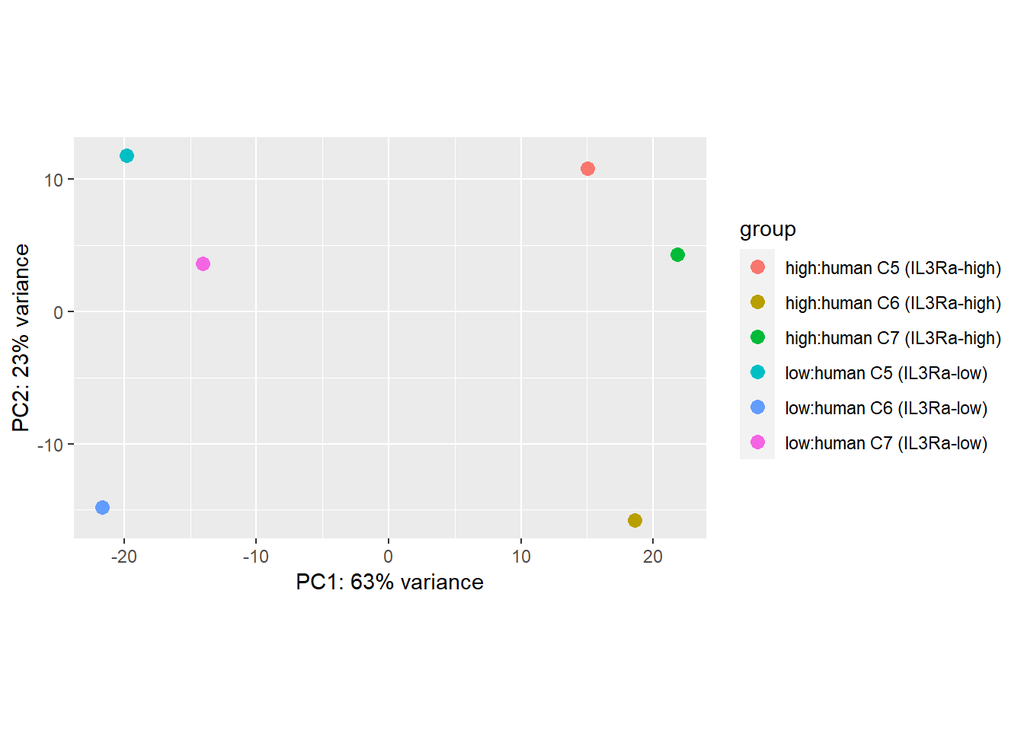

### 1.2) Heatmap of Poisson distances between samples

To confirm the results of our PCA analysis, we additionally calculated the sample-level distance with hierarchical clustering.

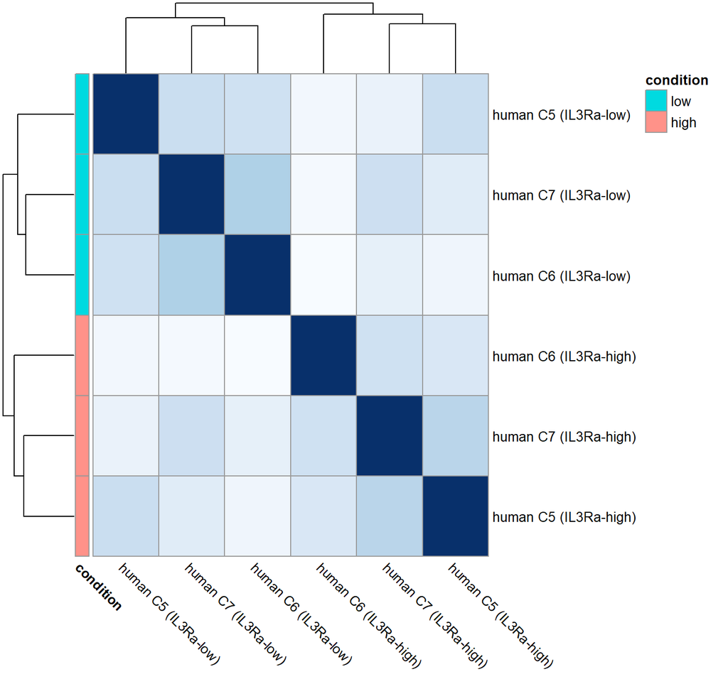

Overall, we still consider the data of high quality and we should be able to detect significant biological differences between our two conditions.

## 2) Differential expression analysis

### 2.1) Calculation of DEGs using `DESeq2`

Differentially-expressed genes (DEGs) were calculated using the R package `DESeq2` with default settings. The used design matrix in this analysis was the comparison of the two levels of condition, high and low.

Additionally, we used a shrinkage method on the raw data counts to shrink the log2 fold changes for the comparison of condition high vs low samples. The results of this analysis revealed 1363 significant DEGs (see **Table 2**).

A DEG was classified as significant when it showed an adjusted p-value smaller 0.01, a log2 fold change greater than or equal 1 and a base mean greater than or equal 20.

|  | baseMean | log2FoldChange | lfcSE | stat | pvalue | padj | GENEID | SYMBOL |
| --- | --- | --- | --- | --- | --- | --- | --- | --- |
| ENSG00000101200.5 | 2579.54476851855 | -3.7927911218385 | 0.306990789386243 | -12.3949097642945 | 2.78459005470727e-35 | 4.77159395803054e-32 | ENSG00000101200 | AVP |
| ENSG00000024422.11 | 4185.65810399576 | -3.54969319532367 | 0.222376729562851 | -15.9506411211111 | 2.81987135881712e-57 | 1.69121784745057e-53 | ENSG00000024422 | EHD2 |
| ENSG00000108924.13 | 5394.46939432504 | -3.2750294163315 | 0.281689294941639 | -11.6452602083136 | 2.42580125994278e-31 | 2.23826816253951e-28 | ENSG00000108924 | HLF |
| ENSG00000165816.12 | 1368.85359306865 | -3.20404564404446 | 0.316742136144085 | -10.1450026741181 | 3.48768869326369e-24 | 1.45455545461115e-21 | ENSG00000165816 | VWA2 |
| ENSG00000039068.18 | 8814.34544575832 | -3.19453053205508 | 0.280669273227967 | -11.4033062410758 | 4.02535780504436e-30 | 3.29210228669367e-27 | ENSG00000039068 | CDH1 |
| ENSG00000071575.11 | 11980.4220771154 | -3.11178676691507 | 0.264917728066164 | -11.7592023111917 | 6.33297784565657e-32 | 6.1592488588095e-29 | ENSG00000071575 | TRIB2 |
| ENSG00000143627.17 | 6248.27136161939 | -3.0764022073538 | 0.253090549287159 | -12.158463870786 | 5.17221260651135e-34 | 6.6472168087611e-31 | ENSG00000143627 | PKLR |
| ENSG00000120278.15 | 2071.48387060897 | -3.05349829815971 | 0.32077128250318 | -9.56896511387973 | 1.07981089600702e-21 | 2.96618283151241e-19 | ENSG00000120278 | PLEKHG1 |
| ENSG00000120279.6 | 3790.33178214861 | -2.94946051194099 | 0.295034876555586 | -10.0171680424639 | 1.28121480606888e-23 | 4.6570216966049e-21 | ENSG00000120279 | MYCT1 |
| ENSG00000229425.2 | 3024.4018189577 | -2.9156852064033 | 0.287740208010161 | -10.1441954552487 | 3.51664094903904e-24 | 1.45455545461115e-21 | ENSG00000229425 | AJ006998.2 |

[output cut: 1353 more lines]

## 3) Plotting results

### 3.1) MA plot

We also had a look at relationship between intensity and difference between log fold change and mean of normalized counts for our two conditions high and low.

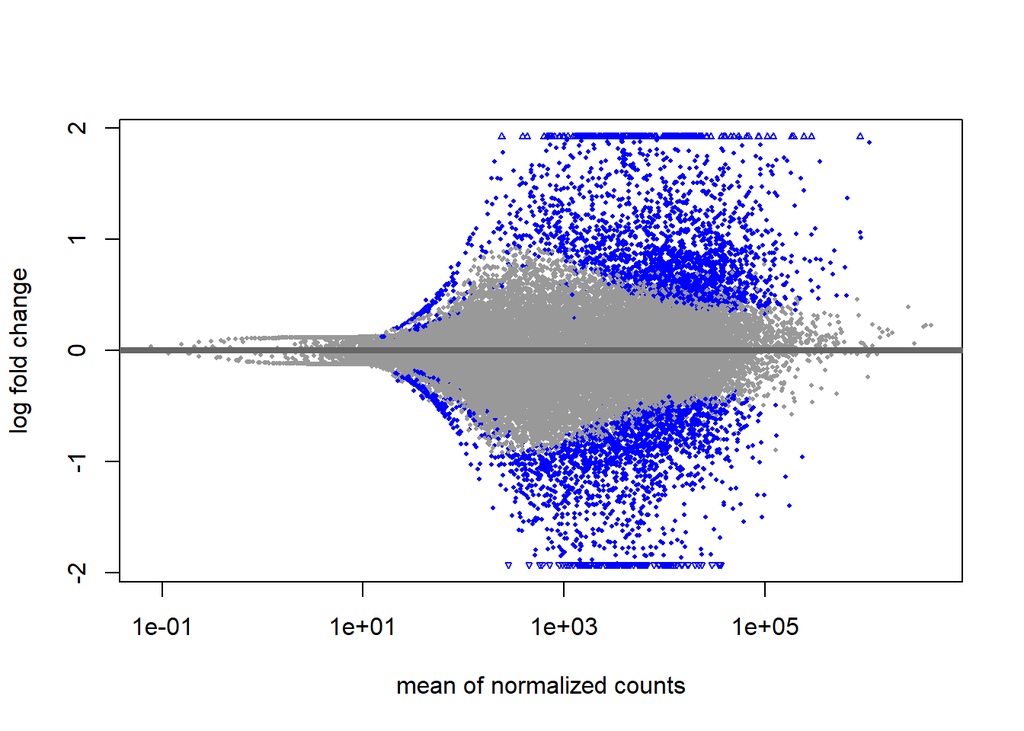

### 3.2) Create a Volcano Plot

The correlation of effect size (`Log2 fold change`) and significance (`-Log10P`) showed a number of significant DEGs (colored in red).

[figure not shown]

## 4) Heatmap showing the top 20 over- and under-expressed DEGs

The top 20 over- and under-expressed DEGs were identified based on their effect size (`Log2 fold change`). The 20 DEGs with the highest and the 20 DEGs with the lowest effect size were selected.

The top 20 over- and under-expressed DEGs were strongly divergent between biological conditions high and low.

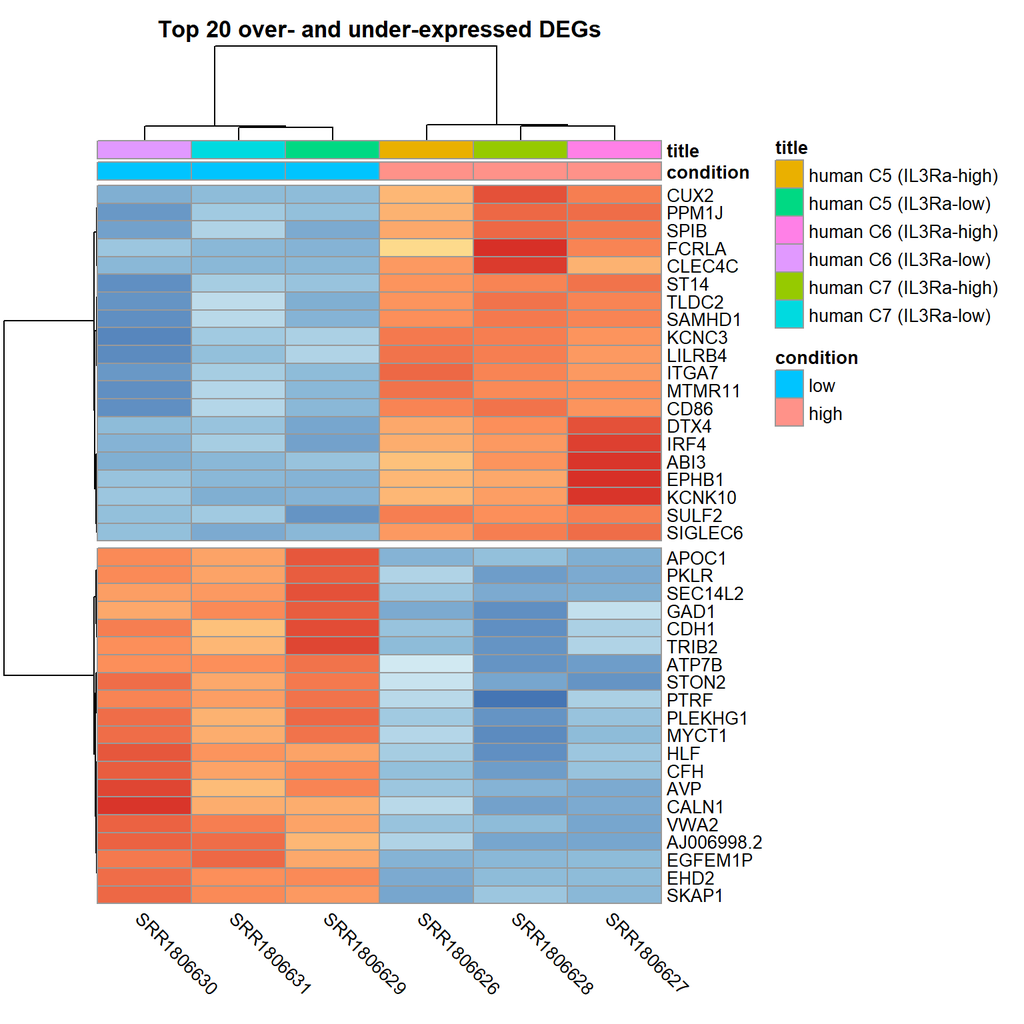

Taken together, these results indicate powerful biological differences between high and low conditions.

## 5) Top 5 pathways of `GSEA` of DEGs

Gene set enrichment analysis (GSEA) was performed with `-log10(FDR)*sign(log2FoldChange)` as the ranking metric and using all available gene set annotations from MSIGDB.

The histogram below shows the calculated GSEA metric for our data.

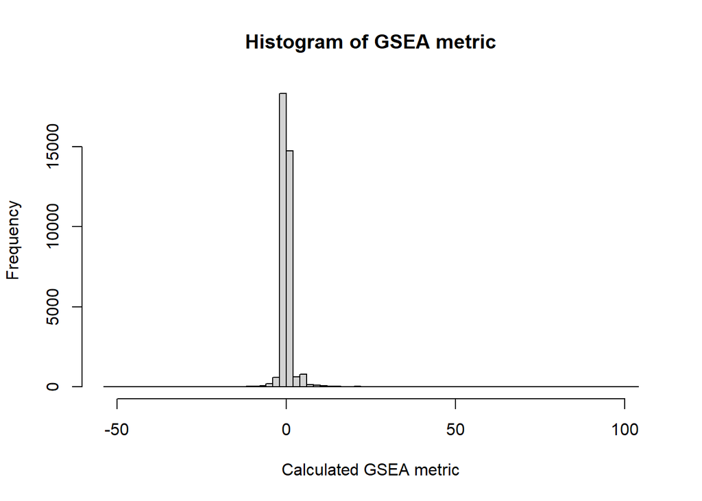

We created a barplot to show the identified top 5 under- and over-expressed pathways based on their calculated normalized enrichment score (NES) by GSEA.

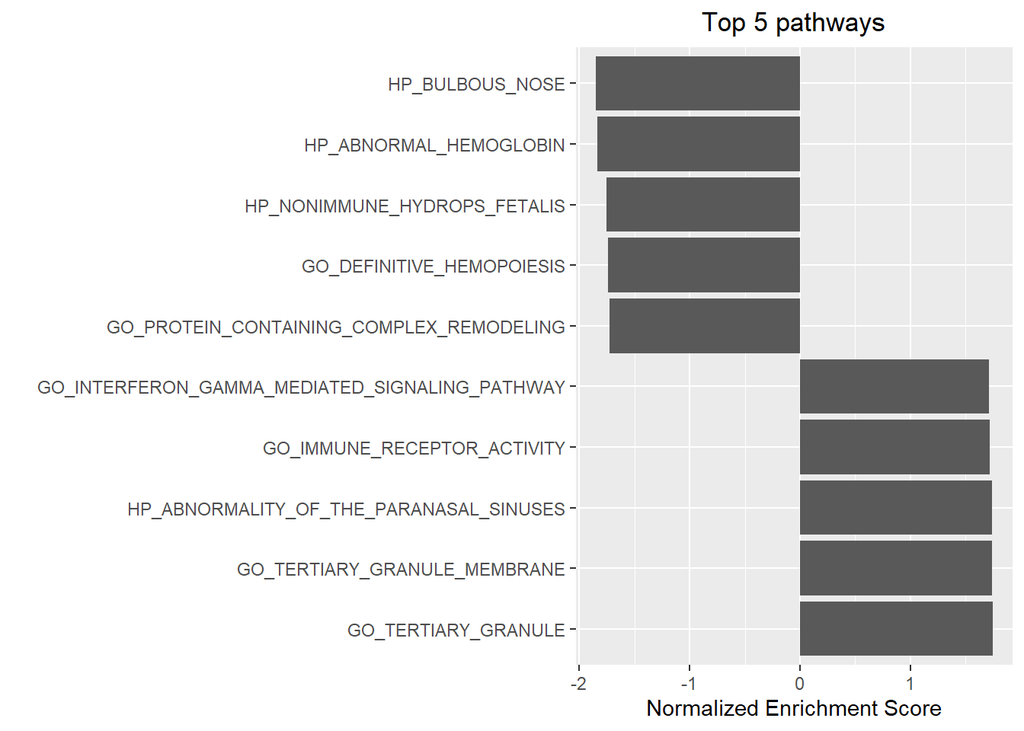

### 5.1) Top 5 over-expressed pathways

The plot below shows the top 5 over-expressed pathways for our GSEA.

How to interpret these plots?

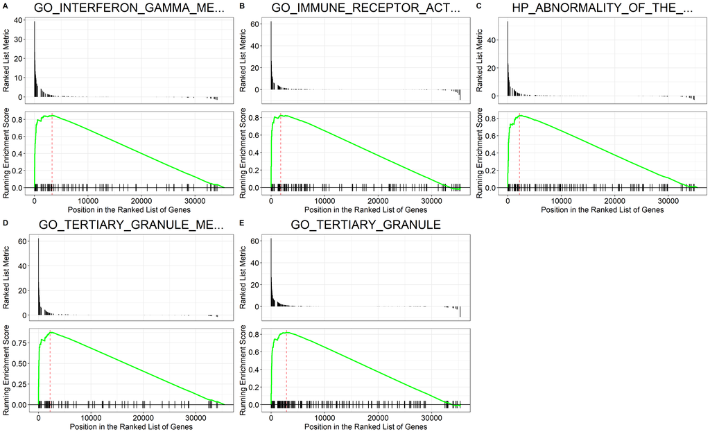

### 5.2) Top 5 under-expressed pathways

The plot below shows the top 5 under-expressed pathways for our GSEA.

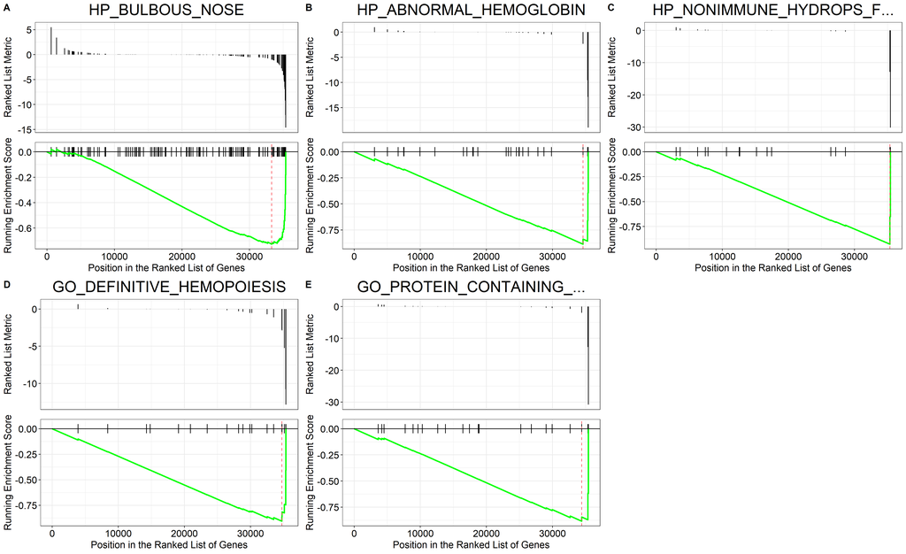

### 5.3) Table of all significant pathways

We found 113 significant results for our GSEA based on an adjusted p-value smaller than or equal to 0.05 (see **Table 3**).

|  | NES | pvalue | p.adjust | core_enrichment |
| --- | --- | --- | --- | --- |
| GO_TERTIARY_GRANULE | 1.74529904206142 | 3.35418475248866e-07 | 0.000801734010463601 | FCER1G/ITGAX/CTSH/CLEC4C/CYBB/SIGLEC14/CFP/LYZ/CYBA/CST3/SIG…… |
| GO_TERTIARY_GRANULE_MEMBRANE | 1.74242801785439 | 4.03631698331071e-06 | 0.00316378786394238 | FCER1G/ITGAX/CLEC4C/CYBB/SIGLEC14/CYBA/SIGLEC5/ITGB2/GAA/CD33/SIRPA/VAMP8/CD93/CD53/CLEC12A/TRPM2/LILRB2/OLR1/CYSTM1/PTAFR/LAMTOR2/GPR84/LAIR1/CD300A/ATP6V0C/MCEMP1 |
| HP_ABNORMALITY_OF_THE_PARANASAL_SINUSES | 1.7381892771953 | 4.63267755414635e-06 | 0.00316378786394238 | CXCR4/HLA-DPA1/CYBB/HLA-DPB1/UNC119/CYBA/IL17RA/CIITA/RUNX2/NCF2/IRF8/SH3KBP1/NCF1/BLNK/MCIDAS/FLNA/MAN2B1/PSMB9/WAS/TAP1/TNFRSF13C/TAP2/ADA/DNAJB13/FUCA1/ICOS/PRKAR1A/DNAI1/TAPBP |
| GO_IMMUNE_RECEPTOR_ACTIVITY | 1.71630534194274 | 1.11565079256671e-05 | 0.00463771183814362 | FCER1G/CXCR4/IL10RA/CD74/HLA-DRA/HLA-DPA1/CTSH/LILRB1/HLA-DOA/IL13RA1/IL17RA/CSF2RA/HLA-DQA1/HLA-DRB1/IL3RA/IL6R/IL12RB1/IL18R1/IL10RB/IL12B/CCR2/IFNGR1/CMKLR1/HLA-DQB2/FLT3/LILRB2/CCR7/PIGR/CCR5 |
| GO_INTERFERON_GAMMA_MEDIATED_SIGNALING_PATHWAY | 1.70852500710563 | 2.10001933090401e-05 | 0.00674423865429119 | IRF4/HCK/HLA-DRA/HLA-DPA1/PRKCD/HLA-DPB1/CIITA/HLA-DQA1/HLA-DRB1/IRF8/HLA-DRB5/IFI30/IRF5/TRIM31/ICAM1/JAK2/IFNGR1/HLA-B/HLA-DQB2/TRIM26/TRIM38/PTAFR/TRIM22/IRF7/CD44/B2M/HLA-H/HLA-C/NCAM1/TRIM34/PTPN… |
| GO_VESICLE_LUMEN | 1.70637215267308 | 3.08699363123491e-08 | 0.000147573730541185 | CTSZ/ANXA2/CTSH/COTL1/FGR/CFP/MVP/PRKCD/TMSB4X/LYZ/GRN/OSCAR…… |
| GO_PHAGOCYTIC_VESICLE | 1.70281924775509 | 2.11617152629156e-05 | 0.00674423865429119 | PLD4/RAB31/CORO1A/CYBB/RAB11FIP1/UNC93B1/CYBA/SRGAP2/NCF2/NOD2/GSN/HVCN1/VIM/UVRAG/ACTG1/CTSS/TCIRG1/ZYX/ATP6V0D1/NCF1/SYK/VAMP8/MPEG1/DMBT1/ATP6V0B/RAPGEF1/WAS/HLA-B/TAP1/RAC2/STXBP2/RAB8A/ATP6V0E1/T… |
| GO_ANTIGEN_PROCESSING_AND_PRESENTATION | 1.69867003199741 | 2.82232406967111e-07 | 0.000801734010463601 | FCER1G/HLA-DMB/CD74/HLA-DRA/HLA-DPA1/CTSH/CYBB/HLA-DOA/LGMN/HLA-DPB1/CYBA/CD1D/CLEC4A/HLA-DMA/HLA-DQA1/CD68/HLA-DRB1/NCF2/NOD2/FGL2/HLA-DRB5/IFI30/PYCARD/AP1S2/CTSS/NCF1/VAMP8/ICAM1/CD207/KIF2B/AP1S3/… |
| GO_POSITIVE_REGULATION_OF_TUMOR_NECROSIS_FACTOR_SUPERFAMILY_CYTOKINE_PRODUCTION | 1.69348872298298 | 3.79996278124836e-05 | 0.00956090635566199 | FCER1G/CD86/CYBB/TYROBP/CYBA/MAPKAPK2/CD2/PTPRJ/NOD2/LRRK2/PYCARD/SASH3/HAVCR2/LILRA2/APP/SYK/IL12B/CCR2/JAK2/IFNGR1/LY96/CCL3/LGALS9/PTAFR/CD14/TLR1/TLR2 |
| GO_MEMBRANE_INVAGINATION | 1.692328339788 | 1.21777816868432e-05 | 0.00485132377949616 | FCER1G/RAB31/ITGB2/GSN/AURKB/SH3BP1/MYH9/SNX18/RAC1/IGLC2/XKR7/ABCA7/RAC2/RHOA/AIF1/CHMP2A/IGHA1/RHOBTB2/CD300A/IGHA2/MARCO/IGHD/XKR8/RHOG/NCKAP1L/ANO6/ARF1/TRDC |

[output cut: 103 more lines]

## 6) Concluding questions

### 6.1) What does this finding imply about IL3R cells?

As stated at the beginning, the biological question of this study was to clarify the lineage relationship between IL3Rαhigh- and IL3Rαlow precursor cells and to find potential molecules involved in their differentiation.

The original paper:

The [original paper](https://doi.org/10.1016/j.stemcr.2015.04.012) categorized the IL3Rαlow subset as common progenitor of granulocytes (GR), macrophages (MΦ), Osteoclasts (OC), and dendritic cells (DC) (**GMODP, common progenitor of GR, MΦ, OC, and DC**) and the IL3Rαhigh as common progenitor of MΦ, OC, and DC (**MODP, common progenitor of MΦ, OC, and DC**).

OCs, MΦs, and DCs are closely related hematopoietic cell lines (blood cells).

However, in cancer and autoimmune and inflammatory diseases, OCs can be promoted by tumors or immune cells, which facilitates bone metastasis, pathological bone loss, and remodeling.

According to the original paper, a ingenuity pathway analysis (IPA) of DEGs indicated a further commitment to MΦ/OC/DC differentiation in the transition from the IL3Rαlow to the IL3Rαhigh phenotype. Additionally, the IL3Rαhigh subset showed higher mRNA expression of transcription factors important for pDC, cDC, and MΦ development.

This RNA-Seq analysis:

First, we had a look at the top 5 over-expressed pathways we found via our GSEA:

Goal was to find connections between our results and the original study, i.e. the impact of IL3Rαhigh- and IL3Rαlow precursor cells on the differentiation of hematopoietic cells and development of the human immune system.

Two over-expressed pathways were related to tertiary granule:

Term [GO_TERTIARY_GRANULE](https://www.gsea-msigdb.org/gsea/msigdb/cards/GOCC_TERTIARY_GRANULE.html) describes “[a] secretory granule that contains cathepsin and gelatinase and is readily exocytosed upon cell activation; found primarily in mature neutrophil cells.”

Term [GO_TERTIARY_GRANULE_MEMBRANE](https://www.gsea-msigdb.org/gsea/msigdb/cards/GOCC_TERTIARY_GRANULE_MEMBRANE.html) describes “the lipid bilayer surrounding a tertiary granule”.

It was an interesting result that these pathways were upregulated as the original paper categorized the IL3Rαlow subset as common progenitor for GR and not IL3Rαhigh.

One over-expressed pathway was related to immune receptor activity:

Term [GO_IMMUNE_RECEPTOR_ACTIVITY](https://www.gsea-msigdb.org/gsea/msigdb/cards/GOMF_IMMUNE_RECEPTOR_ACTIVITY.html) describes “receiving a signal and transmitting it in a cell to initiate an immune response”.

Both IL3Rαhigh- and IL3Rαlow precursor cells play an important role as common progenitor cells in the differentiation of cells involved in the human immune system. Therefore, an over-expressed GSEA pathway to initiate an immune response aligns with our expectations of this analysis.

One over-expressed pathway was related to interferon-gamma signaling pathway:

Term [GO_INTERFERON_GAMMA_MEDIATED_SIGNALING_PATHWAY](https://www.gsea-msigdb.org/gsea/msigdb/cards/GOBP_INTERFERON_GAMMA_MEDIATED_SIGNALING_PATHWAY.html) describes “a series of molecular signals initiated by the binding of interferon-gamma to a receptor on the surface of a cell, and ending with regulation of a downstream cellular process, e.g. transcription.”.

Interferon-gamma is formed in the course of the innate immune response and responsible for, among other things, the activation of MΦs. As before, this result also aligns with the results from the original paper.

The last of the top 5 over-expressed pathways was related to abnormality of the paranasal sinuses, Term HP_ABNORMALITY_OF_THE_PARANASAL_SINUSES. This was an odd result, as it was not directly connected to hematopoietic cells in the human immune system.

Then, we had a look at the identified top 20 over-expressed DEGs for IL3Rαhigh precursor cells.

A sample of the identified DEGS reproduced the results of the original paper:

- Gene [CUX2](https://www.uniprot.org/uniprot/O14529#function), among other things, “regulates dendrite development and branching and dendritic spine formation”.
- Gene [SPIB](https://www.uniprot.org/uniprot/Q01892#function), among other things, “promotes development of plasmacytoid dendritic cells (pDCs)”.
- Gene [CLEC4C](https://www.uniprot.org/uniprot/Q8WTT0#function), among other things, “is a cell surface receptor which may play a role in antigen capturing by dendritic cells”.
- Gene [SAMHD1](https://www.uniprot.org/uniprot/Q9Y3Z3#function), among other things, “plays a role in regulation of the innate immune response”.

### 6.2) What does this tell us about development of the immune system?

Hematopoietic cells play an important role in the immune systems. The results from the original study showed that the IL3Rα expression level discriminates two successive stages in commitment toward the OC, MΦ, and DC fate.

The concentration of certain factors (in our example IL3Rαlow and IL3Rαhigh) contribute to the explained differentiation of pluripotent progenitor cells.

However, in cancer and autoimmune and inflammatory diseases, over- and under-expression of IL3Rαlow and IL3Rαhigh can be promoted by tumors or immune cells, which facilitates bone metastasis, pathological bone loss, and remodeling.

### 6.3) Why does this matter within the context of the developmental biology field?

Understanding the development of OC, DC, and MΦ is important for clinical diagnostics, targeted drug-based therapy, and cellular therapy.